# STATS_418_HW4

Yuan Song (204877123)

June 6, 2017

# Dataset Introduction

The Adult Census Income Binary Classification dataset I am going to use is publicly available at the UCI Machine Learning Repository. This data derives from census data, and consists of information about 48842 individuals and their annual income. The predict variable is that if an individual earns >50k a year or <=50K a year, and I set >50K as 1, <=50K as 0.

The dataset is made up of the following fields. 1. Age: continuous 2. Workclass: 8 values 3. Fnlwgt: continuous. 4. Education: 16 values 5. Education-num: continuous. 6. Marital-status: 7 values 7. Occupation: 14 values 8. Relationship: 6 values 9. Race: 5 values 10. Sex: Male, Female 11. Capital-gain: continuous. 12. Capital-loss: continuous. 13. Hours-per-week: continuous. 14. Native-country: 41 values 15. >50K Income: Yes, No

In the following, I will use various algorithms (Neural Networks, hyperparameter optimization for GBMs with random search, and ensembling various models) with implementations of h2o, and use various values for the hyperparameters (tuning).

```r
library(gbm)
library(h2o)
```

```r
library(ggplot2)
library(dplyr)
library(readxl)
library(glmnet)
library(MASS)
library(randomForest)
library(ROCR)
library(xgboost)
library(tidyverse)
library(data.table)
library(dtplyr)
library(forcats)
library(grid)
library(gridExtra)
testdata <- read.table("https://archive.ics.uci.edu/ml/machine-learning-databases/adult/adult.data", sep = ",", col.names = c("age", "workclass", "fnlwgt", "education", "education-num", "marital-status", "occupation", "relationship", "race", "sex", "capital-gain", "capital-loss", "hours-per-week", "native-country", "earnings"))
data <- read.table("https://archive.ics.uci.edu/ml/machine-learning-databases/adult/adult.data", sep = ",", col.names = c("age", "workclass", "fnlwgt", "education", "education-num", "marital-status", "occupation", "relationship", "race", "sex", "capital-gain", "capital-loss", "hours-per-week", "native-country", "earnings"))

d <- rbind(testdata, data)
Y<-as.factor(d$Y)
d$Y[d$earnings == " <=50K"] <- 0
d$Y[d$earnings == " >50K"] <- 1
d[[15]]<-NULL
```

# Split of train, validation and test set

The data was split into a training, a validation and a test set by using the probability of 0.6, 0.2, and 0.2.

```r
set.seed(123)
idx <- sample(seq(1, 3), size = nrow(d), replace = TRUE, prob = c(.6, .2, .2))
d_train <- d[idx == 1,]
d_validation <- d[idx == 2,]
d_test <- d[idx == 3,]

X <- Matrix::sparse.model.matrix(Y ~ . -1, data = d)
X_train <- X[idx == 1,]
X_validation <- X[idx == 2,]
X_test <- X[idx == 3,]

# h2o
h2o.init(nthreads=-1)
```

[output not shown]

```r
dx <- h2o.importFile("https://archive.ics.uci.edu/ml/machine-learning-databases/adult/adult.data", sep = ",", col.names = c("age", "workclass", "fnlwgt", "education", "education-num", "marital-status", "occupation", "relationship", "race", "sex", "capital-gain", "capital-loss", "hours-per-week", "native-country", "earnings"))
Y<-as.factor(dx$Y)
dx_split <- h2o.splitFrame(dx, ratios = c(0.6,0.2), seed = 123)
dx_train <- dx_split[[1]]
dx_validation <- dx_split[[2]]
dx_test <- dx_split[[3]]
Xnames <- names(dx_train)[which(names(dx_train)!="Y")]
```

## Method 1 - Neural Net

Neural networks are typically organized in layers. Layers are made up of a number of interconnected “nodes” which contain an “activation function”. Patterns are presented to the network via the “input layer”, which communicates to one or more “hidden layers”. The hidden layers then link to an ‘output layer’.

The activation function is defined as the mapping of the input to the output via a non-linear transform function at each “node”. An epoch is a complete pass through a given dataset. Momentum is a value between 0 and 1 that increases the size of the steps taken towards the minimum by trying to jump from a local minima.

```r
h2o.init(nthreads=-1)
```

```
##  Connection successful!
##
## R is connected to the H2O cluster:
##     H2O cluster uptime:         8 seconds 467 milliseconds
##     H2O cluster version:        3.10.4.6
##     H2O cluster version age:    1 month and 11 days
##     H2O cluster name:           H2O_started_from_R_clarasong_zbe149
##     H2O cluster total nodes:    1
##     H2O cluster total memory:   0.87 GB
##     H2O cluster total cores:    4
##     H2O cluster allowed cores:  4
##     H2O cluster healthy:        TRUE
##     H2O Connection ip:          localhost
##     H2O Connection port:        54321
##     H2O Connection proxy:       NA
##     H2O Internal Security:      FALSE
##     R Version:                  R version 3.3.2 (2016-10-31)
```

```r
nn1 <- h2o.deeplearning(x = Xnames, y = "earnings", training_frame = dx_train, validation_frame = dx_validation,
            activation = "Rectifier", hidden = c(200,200),
            epochs = 100, stopping_rounds = 2, stopping_metric = "AUC", stopping_tolerance = 0)
h2o.performance(nn1, dx_test)@metrics$AUC
```

```
## [1] 0.9102214
```

```r
nn2 <- h2o.deeplearning(x = Xnames, y = "earnings", training_frame = dx_train, validation_frame = dx_validation,
            activation = "Rectifier", hidden = c(50,50,50,50),
            epochs = 100, stopping_rounds = 2, stopping_metric = "AUC", stopping_tolerance = 0)
h2o.performance(nn2, dx_test)@metrics$AUC
```

```
## [1] 0.9141735
```

```r
nn3 <- h2o.deeplearning(x = Xnames, y = "earnings", training_frame = dx_train, validation_frame = dx_validation,
            activation = "Rectifier", hidden = c(20),
            epochs = 100, stopping_rounds = 2, stopping_metric = "AUC", stopping_tolerance = 0)
h2o.performance(nn3, dx_test)@metrics$AUC
```

```
## [1] 0.9119858
```

```r
nn4 <- h2o.deeplearning(x = Xnames, y = "earnings", training_frame = dx_train, validation_frame = dx_validation,
            activation = "Rectifier", hidden = c(200,200),
            rho = 0.95, epsilon = 1e-06,  ## default:  rho = 0.99, epsilon = 1e-08
            epochs = 100, stopping_rounds = 2, stopping_metric = "AUC", stopping_tolerance = 0)
h2o.performance(nn4, dx_test)@metrics$AUC
```

```
## [1] 0.9092877
```

```r
nn5 <- h2o.deeplearning(x = Xnames, y = "earnings", training_frame = dx_train, validation_frame = dx_validation,
            activation = "Rectifier", hidden = c(200,200),
            rho = 0.999, epsilon = 1e-08,  ## default:  rho = 0.99, epsilon = 1e-08
            epochs = 100, stopping_rounds = 2, stopping_metric = "AUC", stopping_tolerance = 0)
h2o.performance(nn5, dx_test)@metrics$AUC
```

```
## [1] 0.9136284
```

```r
nn6 <- h2o.deeplearning(x = Xnames, y = "earnings", training_frame = dx_train, validation_frame = dx_validation,
            activation = "Rectifier", hidden = c(200,200),
            adaptive_rate = FALSE, ## default: rate = 0.005, rate_decay = 1, momentum_stable = 0,
            epochs = 100, stopping_rounds = 2, stopping_metric = "AUC", stopping_tolerance = 0)
h2o.performance(nn6, dx_test)@metrics$AUC
```

```
## [1] 0.9119073
```

```r
nn7 <- h2o.deeplearning(x = Xnames, y = "earnings", training_frame = dx_train, validation_frame = dx_validation,
            activation = "Rectifier", hidden = c(200,200),
            adaptive_rate = FALSE, rate = 0.001, momentum_start = 0.5, momentum_ramp = 1e5, momentum_stable = 0.99,
            epochs = 100, stopping_rounds = 2, stopping_metric = "AUC", stopping_tolerance = 0)
h2o.performance(nn7, dx_test)@metrics$AUC
```

```
## [1] 0.9116694
```

```r
nn8 <- h2o.deeplearning(x = Xnames, y = "earnings", training_frame = dx_train, validation_frame = dx_validation,
            activation = "Rectifier", hidden = c(200,200),
            adaptive_rate = FALSE, rate = 0.01, rate_annealing = 1e-05,
            momentum_start = 0.5, momentum_ramp = 1e4, momentum_stable = 0.9,
            epochs = 100, stopping_rounds = 2, stopping_metric = "AUC", stopping_tolerance = 0)
h2o.performance(nn8, dx_test)@metrics$AUC
```

```
## [1] 0.9138508
```

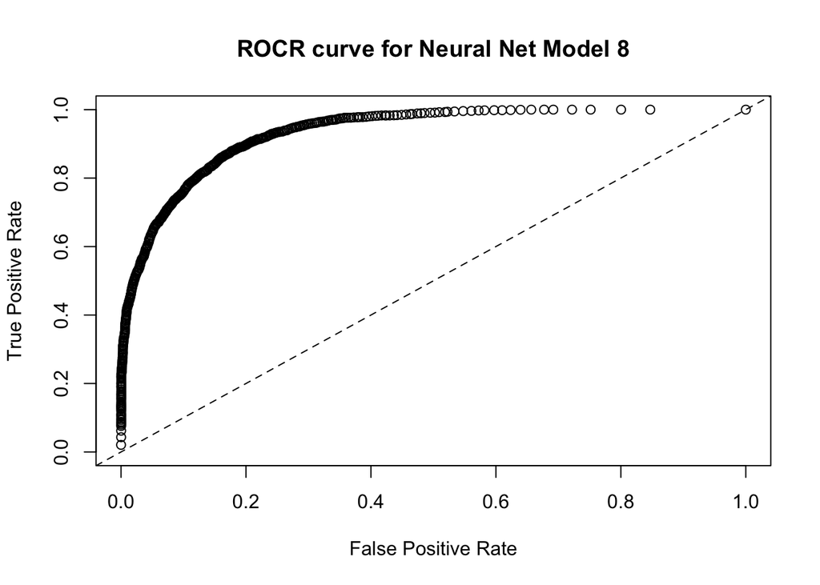

```r
nn8_pref <- h2o.performance(nn8)
plot(nn8_pref,main= "ROCR curve for Neural Net Model 8")
```

## Hyperparameter Optimization for GBMs with Random Search

```r
hyper_params <- list( ntrees = 100,  ## early stopping
                     max_depth = 5:15,
                     min_rows = c(1,3,10,30,100),
                     learn_rate = c(0.01,0.03,0.1),
                     learn_rate_annealing = c(0.99,0.995,1,1),
                     sample_rate = c(0.4,0.7,1,1),
                     col_sample_rate = c(0.7,1,1),
                     nbins = c(30,100,300),
                     nbins_cats = c(64,256,1024)
)

search_criteria <- list( strategy = "RandomDiscrete",
                        max_runtime_secs = 10*3600,
                        max_models = 100
)


mds <- h2o.grid(algorithm = "gbm", grid_id = "grd",
                  x = Xnames, y = "earnings", training_frame = dx_train,
                  validation_frame = dx_validation,
                  hyper_params = hyper_params,
                  search_criteria = search_criteria,
                  stopping_metric = "AUC", stopping_tolerance = 1e-3, stopping_rounds = 2,
                  seed = 123)
mds_sort <- h2o.getGrid(grid_id = "grd", sort_by = "auc", decreasing = TRUE)
mds_sort
```

```
## H2O Grid Details
## ================
##
## Grid ID: grd
## Used hyper parameters:
##   -  col_sample_rate
##   -  learn_rate
##   -  learn_rate_annealing
##   -  max_depth
##   -  min_rows
##   -  nbins
##   -  nbins_cats
##   -  ntrees
##   -  sample_rate
## Number of models: 100
## Number of failed models: 0
##
## Hyper-Parameter Search Summary: ordered by decreasing auc
##   col_sample_rate learn_rate learn_rate_annealing max_depth min_rows nbins
## 1             1.0        0.1                0.995         5    100.0   100
## 2             1.0       0.03                  1.0        11     10.0    30
## 3             1.0        0.1                 0.99        11      1.0    30
## 4             1.0        0.1                0.995        15     10.0    30
## 5             1.0        0.1                  1.0         9     30.0   300
##   nbins_cats ntrees sample_rate    model_ids                auc
## 1        256    100         1.0 grd_model_22 0.9201240559038724
## 2         64    100         1.0 grd_model_11 0.9155632696917101
## 3        256    100         1.0 grd_model_60 0.9143081482531025
## 4       1024    100         1.0 grd_model_39 0.9139387093515534
## 5         64    100         1.0 grd_model_58 0.9132175425753407
##
## ---
##     col_sample_rate learn_rate learn_rate_annealing max_depth min_rows
## 95              1.0       0.03                0.995         5      3.0
## 96              1.0       0.01                0.995        11      1.0
## 97              1.0       0.01                0.995        12      1.0
## 98              1.0       0.01                0.995         5     30.0
## 99              1.0       0.03                 0.99        13      1.0
## 100             1.0       0.01                0.995        14      1.0
##     nbins nbins_cats ntrees sample_rate    model_ids                auc
## 95    100       1024    100         1.0 grd_model_99 0.8938809714039072
## 96    300       1024    100         1.0 grd_model_72 0.8928214584177886
## 97    100         64    100         1.0  grd_model_8 0.8902018663486554
## 98     30       1024    100         1.0 grd_model_69 0.8895466239502937
## 99    100        256    100         1.0 grd_model_35 0.8859496455826731
## 100   100         64    100         1.0 grd_model_10 0.8586839132710692
```

```r
md_best <- h2o.getModel(mds_sort@model_ids[[1]])
summary(md_best)
```

```
## Model Details:
## ==============
##
## H2OBinomialModel: gbm
## Model Key:  grd_model_22
## Model Summary:
##   number_of_trees number_of_internal_trees model_size_in_bytes min_depth
## 1             100                      100              137632         5
##   max_depth mean_depth min_leaves max_leaves mean_leaves
## 1         5    5.00000          9         24    16.95000
##
## H2OBinomialMetrics: gbm
## ** Reported on training data. **
##
## MSE:  0.08331931
## RMSE:  0.2886508
## LogLoss:  0.2662766
## Mean Per-Class Error:  0.1593658
## AUC:  0.9375511
## Gini:  0.8751022
##
## Confusion Matrix (vertical: actual; across: predicted) for F1-optimal threshold:
##        <=50K >50K    Error         Rate
## <=50K  13525 1353 0.090940  =1353/14878
## >50K    1077 3651 0.227792   =1077/4728
## Totals 14602 5004 0.123942  =2430/19606
##
## Maximum Metrics: Maximum metrics at their respective thresholds
##                         metric threshold    value idx
## 1                       max f1  0.373646 0.750308 206
## 2                       max f2  0.164783 0.822350 290
## 3                 max f0point5  0.651395 0.783601 113
## 4                 max accuracy  0.471804 0.882893 171
## 5                max precision  0.992825 1.000000   0
## 6                   max recall  0.012807 1.000000 385
## 7              max specificity  0.992825 1.000000   0
## 8             max absolute_mcc  0.375922 0.668455 205
## 9   max min_per_class_accuracy  0.276158 0.853003 242
## 10 max mean_per_class_accuracy  0.216092 0.856479 266
##
```

[output cut: 93 more lines]

```
##          variable relative_importance scaled_importance percentage
## 1    relationship         2869.962158          1.000000   0.275714
## 2    capital-gain         1967.750000          0.685636   0.189040
## 3       education         1688.988159          0.588505   0.162259
## 4  marital-status         1080.018677          0.376318   0.103756
## 5      occupation         1034.143311          0.360333   0.099349
## 6             age          569.045227          0.198276   0.054668
## 7    capital-loss          565.673584          0.197101   0.054344
## 8  hours-per-week          255.406494          0.088993   0.024537
## 9       workclass          157.518829          0.054885   0.015133
## 10 native-country          132.886078          0.046302   0.012766
## 11         fnlwgt           47.795952          0.016654   0.004592
## 12            sex           22.885508          0.007974   0.002199
## 13           race           13.451735          0.004687   0.001292
## 14  education-num            3.657629          0.001274   0.000351
```

```r
h2o.auc(h2o.performance(md_best, dx_test))
```

```
## [1] 0.9242823
```

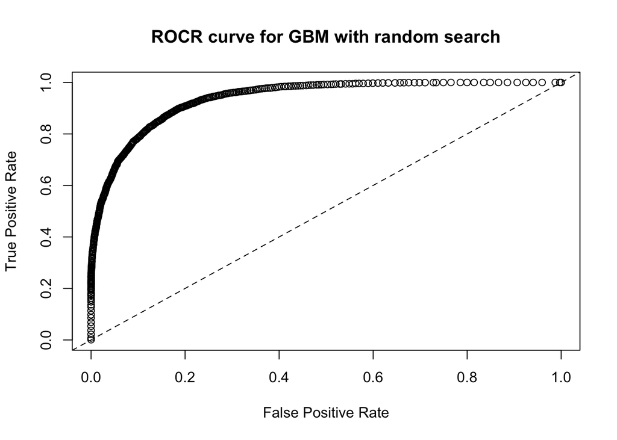

```r
md_best_pref <- h2o.performance(md_best)
plot(md_best_pref,main= "ROCR curve for GBM with random search")
```

## Ensembles

Ensemble modeling is the process of running two or more related but different analytical models and then synthesizing the results into a single score to improve the accuracy of predictive analytics and data mining applications.

```r
md1 <- h2o.glm(x = Xnames, y = "earnings", training_frame = dx_train,
                family = "binomial",
                alpha = 1, lambda = 0,
                seed = 123,
                nfolds = 5, fold_assignment = "Modulo", keep_cross_validation_predictions = TRUE)
md2 <- h2o.randomForest(x = Xnames, y = "earnings", training_frame = dx_train,
                ntrees = 100,
                seed = 123,
                nfolds = 5, fold_assignment = "Modulo", keep_cross_validation_predictions = TRUE)
md3 <- h2o.gbm(x = Xnames, y = "earnings", training_frame = dx_train, distribution = "bernoulli",
                ntrees = 100, max_depth = 10, learn_rate = 0.1,
                nbins = 100, seed = 123,
                nfolds = 5, fold_assignment = "Modulo", keep_cross_validation_predictions = TRUE)
md4 <- h2o.deeplearning(x = Xnames, y = "earnings", training_frame = dx_train,
            epochs = 5,
            seed = 123,
            nfolds = 5, fold_assignment = "Modulo", keep_cross_validation_predictions = TRUE)
md_ens <- h2o.stackedEnsemble(x = Xnames, y = "earnings", training_frame = dx_train,
                    base_models = list(md1@model_id, md2@model_id, md3@model_id, md4@model_id))
h2o.auc(h2o.performance(md1, dx_test))
```

```
## [1] 0.9104718
```

```r
h2o.auc(h2o.performance(md2, dx_test))
```

```
## [1] 0.9149446
```

```r
h2o.auc(h2o.performance(md3, dx_test))
```

```
## [1] 0.9224996
```

```r
h2o.auc(h2o.performance(md4, dx_test))
```

```
## [1] 0.9103396
```

```r
h2o.auc(h2o.performance(md_ens, dx_test))
```

```
## [1] 0.9234174
```

```r
h2o.getModel(md_ens@model$metalearner$name)@model$coefficients_table
```

```
## Coefficients: glm coefficients
##                                     names coefficients
## 1                               Intercept    -3.249265
## 2          GLM_model_R_1496825445586_5018     1.587845
## 3          DRF_model_R_1496825445586_5036     1.554870
## 4          GBM_model_R_1496825445586_5243     3.028662
## 5 DeepLearning_model_R_1496825445586_5460     0.435373
##   standardized_coefficients
## 1                 -1.690935
## 2                  0.458377
## 3                  0.463215
## 4                  0.979169
## 5                  0.127150
```

## Training Time Required

```r
# Neural Nets
summary(nn8) # 1 min 28.549 sec
```

```
## Model Details:
## ==============
##
## H2OBinomialModel: deeplearning
## Model Key:  DeepLearning_model_R_1496825445586_101
## Status of Neuron Layers: predicting earnings, 2-class classification, bernoulli distribution, CrossEntropy loss, 64,002 weights/biases, 508.4 KB, 372,514 training samples, mini-batch size 1
##   layer units      type dropout       l1       l2 mean_rate rate_rms
## 1     1   116     Input  0.00 %
## 2     2   200 Rectifier  0.00 % 0.000000 0.000000  0.002116 0.000000
## 3     3   200 Rectifier  0.00 % 0.000000 0.000000  0.002116 0.000000
## 4     4     2   Softmax         0.000000 0.000000  0.002116 0.000000
##   momentum mean_weight weight_rms mean_bias bias_rms
## 1
## 2 0.900000   -0.005024   0.091548  0.431908 0.036417
## 3 0.900000   -0.016843   0.073753  0.939619 0.017870
## 4 0.900000    0.024045   0.346471 -0.003334 0.376104
##
## H2OBinomialMetrics: deeplearning
## ** Reported on training data. **
## ** Metrics reported on temporary training frame with 9994 samples **
##
## MSE:  0.08712912
## RMSE:  0.2951764
## LogLoss:  0.2743823
## Mean Per-Class Error:  0.1627925
## AUC:  0.9326631
## Gini:  0.8653261
##
## Confusion Matrix (vertical: actual; across: predicted) for F1-optimal threshold:
##        <=50K >50K    Error        Rate
## <=50K   6759  820 0.108194   =820/7579
## >50K     525 1890 0.217391   =525/2415
## Totals  7284 2710 0.134581  =1345/9994
##
## Maximum Metrics: Maximum metrics at their respective thresholds
##                         metric threshold    value idx
## 1                       max f1  0.368429 0.737561 214
## 2                       max f2  0.156663 0.817248 303
## 3                 max f0point5  0.627540 0.768279 119
## 4                 max accuracy  0.506012 0.876826 163
```

[output cut: 63 more lines]

```
## 3                       0.15139         0.31707            0.31472
## 4                       0.14599         0.31698            0.31286
## 5                       0.13458         0.31715            0.31442
## 6                       0.13238         0.31841            0.31548
## 7                       0.13048         0.32003            0.31931
## 8                       0.13458         0.31715            0.31442
##   validation_auc validation_lift validation_classification_error
## 1
## 2        0.90654         4.27326                         0.17727
## 3        0.90834         4.27326                         0.16639
## 4        0.90820         4.27326                         0.17129
## 5        0.90857         4.27326                         0.17252
## 6        0.90807         4.27326                         0.17206
## 7        0.90525         4.27326                         0.16838
## 8        0.90857         4.27326                         0.17252
```

```r
# GBM with random search
summary(md_best) # 4 min  1.381 sec
```

```
## Model Details:
## ==============
##
## H2OBinomialModel: gbm
## Model Key:  grd_model_22
## Model Summary:
##   number_of_trees number_of_internal_trees model_size_in_bytes min_depth
## 1             100                      100              137632         5
##   max_depth mean_depth min_leaves max_leaves mean_leaves
## 1         5    5.00000          9         24    16.95000
##
## H2OBinomialMetrics: gbm
## ** Reported on training data. **
##
## MSE:  0.08331931
## RMSE:  0.2886508
## LogLoss:  0.2662766
## Mean Per-Class Error:  0.1593658
## AUC:  0.9375511
## Gini:  0.8751022
##
## Confusion Matrix (vertical: actual; across: predicted) for F1-optimal threshold:
##        <=50K >50K    Error         Rate
## <=50K  13525 1353 0.090940  =1353/14878
## >50K    1077 3651 0.227792   =1077/4728
## Totals 14602 5004 0.123942  =2430/19606
##
## Maximum Metrics: Maximum metrics at their respective thresholds
##                         metric threshold    value idx
## 1                       max f1  0.373646 0.750308 206
## 2                       max f2  0.164783 0.822350 290
## 3                 max f0point5  0.651395 0.783601 113
## 4                 max accuracy  0.471804 0.882893 171
## 5                max precision  0.992825 1.000000   0
## 6                   max recall  0.012807 1.000000 385
## 7              max specificity  0.992825 1.000000   0
## 8             max absolute_mcc  0.375922 0.668455 205
## 9   max min_per_class_accuracy  0.276158 0.853003 242
## 10 max mean_per_class_accuracy  0.216092 0.856479 266
##
```

[output cut: 93 more lines]

```
##          variable relative_importance scaled_importance percentage
## 1    relationship         2869.962158          1.000000   0.275714
## 2    capital-gain         1967.750000          0.685636   0.189040
## 3       education         1688.988159          0.588505   0.162259
## 4  marital-status         1080.018677          0.376318   0.103756
## 5      occupation         1034.143311          0.360333   0.099349
## 6             age          569.045227          0.198276   0.054668
## 7    capital-loss          565.673584          0.197101   0.054344
## 8  hours-per-week          255.406494          0.088993   0.024537
## 9       workclass          157.518829          0.054885   0.015133
## 10 native-country          132.886078          0.046302   0.012766
## 11         fnlwgt           47.795952          0.016654   0.004592
## 12            sex           22.885508          0.007974   0.002199
## 13           race           13.451735          0.004687   0.001292
## 14  education-num            3.657629          0.001274   0.000351
```

```r
# Ensembling
summary(md1) # 0.144 sec
```

```
## Model Details:
## ==============
##
## H2OBinomialModel: glm
## Model Key:  GLM_model_R_1496825445586_5018
## GLM Model: summary
##     family  link regularization number_of_predictors_total
## 1 binomial logit           None                        100
##   number_of_active_predictors number_of_iterations  training_frame
## 1                         100                    7 RTMP_sid_8e64_2
##
## H2OBinomialMetrics: glm
## ** Reported on training data. **
##
## MSE:  0.1005462
## RMSE:  0.3170903
## LogLoss:  0.3140635
## Mean Per-Class Error:  0.1865668
## AUC:  0.9101626
## Gini:  0.8203252
## R^2:  0.450558
## Null Deviance:  21660.81
## Residual Deviance:  12315.06
## AIC:  12517.06
##
## Confusion Matrix (vertical: actual; across: predicted) for F1-optimal threshold:
##        <=50K >50K    Error         Rate
## <=50K  12917 1961 0.131805  =1961/14878
## >50K    1141 3587 0.241328   =1141/4728
## Totals 14058 5548 0.158217  =3102/19606
##
## Maximum Metrics: Maximum metrics at their respective thresholds
##                         metric threshold    value idx
## 1                       max f1  0.341870 0.698132 212
## 2                       max f2  0.147298 0.795138 294
## 3                 max f0point5  0.549221 0.715924 140
## 4                 max accuracy  0.546293 0.854075 141
## 5                max precision  0.994716 0.993548   3
## 6                   max recall  0.000864 1.000000 398
## 7              max specificity  0.999781 0.999866   0
```

[output cut: 95 more lines]

```
##                               names coefficients sign
## 1               education.Preschool     4.504685  NEG
## 2  marital-status.Married-AF-spouse     2.580524  POS
## 3                      capital-gain     2.418849  POS
## 4           native-country.Columbia     2.367086  NEG
## 5 marital-status.Married-civ-spouse     2.315578  POS
##
## ---
##                          names coefficients sign
## 95      workclass.Never-worked     0.045002  NEG
## 96  native-country.El-Salvador     0.031255  NEG
## 97      native-country.Jamaica     0.020082  NEG
## 98  workclass.Self-emp-not-inc     0.018520  POS
## 99                  race.Other     0.006123  POS
## 100       native-country.China     0.004817  POS
```

```r
summary(md2) # 56.516 sec
```

```
## Model Details:
## ==============
##
## H2OBinomialModel: drf
## Model Key:  DRF_model_R_1496825445586_5036
## Model Summary:
##   number_of_trees number_of_internal_trees model_size_in_bytes min_depth
## 1             100                      100             2040687        20
##   max_depth mean_depth min_leaves max_leaves mean_leaves
## 1        20   20.00000       1190       1709  1480.94000
##
## H2OBinomialMetrics: drf
## ** Reported on training data. **
## ** Metrics reported on Out-Of-Bag training samples **
##
## MSE:  0.09544098
## RMSE:  0.3089352
## LogLoss:  0.3240427
## Mean Per-Class Error:  0.1853813
## AUC:  0.9148775
## Gini:  0.829755
##
## Confusion Matrix (vertical: actual; across: predicted) for F1-optimal threshold:
##        <=50K >50K    Error         Rate
## <=50K  13418 1460 0.098131  =1460/14878
## >50K    1289 3439 0.272631   =1289/4728
## Totals 14707 4899 0.140212  =2749/19606
##
## Maximum Metrics: Maximum metrics at their respective thresholds
##                         metric threshold    value idx
## 1                       max f1  0.407518 0.714449 200
## 2                       max f2  0.176636 0.788117 297
## 3                 max f0point5  0.572820 0.744797 141
## 4                 max accuracy  0.513997 0.865449 162
## 5                max precision  0.999842 1.000000   0
## 6                   max recall  0.000006 1.000000 399
## 7              max specificity  0.999842 1.000000   0
## 8             max absolute_mcc  0.431889 0.622629 191
## 9   max min_per_class_accuracy  0.290008 0.828257 248
## 10 max mean_per_class_accuracy  0.246066 0.828788 266
```

[output cut: 142 more lines]

```
##          variable relative_importance scaled_importance percentage
## 1    relationship        27699.574219          1.000000   0.142053
## 2  marital-status        26443.667969          0.954660   0.135612
## 3    capital-gain        26349.761719          0.951270   0.135131
## 4      occupation        20008.943359          0.722356   0.102613
## 5             age        19350.451172          0.698583   0.099236
## 6       education        13547.631836          0.489092   0.069477
## 7   education-num        13518.998047          0.488058   0.069330
## 8          fnlwgt        11886.741211          0.429131   0.060959
## 9  hours-per-week        11212.376953          0.404785   0.057501
## 10      workclass         7367.773926          0.265989   0.037785
## 11   capital-loss         7046.657227          0.254396   0.036138
## 12 native-country         5525.513184          0.199480   0.028337
## 13            sex         2722.106201          0.098272   0.013960
## 14           race         2314.167236          0.083545   0.011868
```

```r
summary(md3) # 41.317 sec
```

```
## Model Details:
## ==============
##
## H2OBinomialModel: gbm
## Model Key:  GBM_model_R_1496825445586_5243
## Model Summary:
##   number_of_trees number_of_internal_trees model_size_in_bytes min_depth
## 1             100                      100              332278        10
##   max_depth mean_depth min_leaves max_leaves mean_leaves
## 1        10   10.00000         75        249   167.73000
##
## H2OBinomialMetrics: gbm
## ** Reported on training data. **
##
## MSE:  0.04330704
## RMSE:  0.2081034
## LogLoss:  0.1510087
## Mean Per-Class Error:  0.07427868
## AUC:  0.9865414
## Gini:  0.9730828
##
## Confusion Matrix (vertical: actual; across: predicted) for F1-optimal threshold:
##        <=50K >50K    Error         Rate
## <=50K  14345  533 0.035825   =533/14878
## >50K     533 4195 0.112733    =533/4728
## Totals 14878 4728 0.054371  =1066/19606
##
## Maximum Metrics: Maximum metrics at their respective thresholds
##                         metric threshold    value idx
## 1                       max f1  0.436865 0.887267 192
## 2                       max f2  0.304342 0.918924 238
## 3                 max f0point5  0.582213 0.911551 147
## 4                 max accuracy  0.478135 0.946598 179
## 5                max precision  0.998329 1.000000   0
## 6                   max recall  0.017666 1.000000 374
## 7              max specificity  0.998329 1.000000   0
## 8             max absolute_mcc  0.478135 0.851980 179
## 9   max min_per_class_accuracy  0.341381 0.936887 225
## 10 max mean_per_class_accuracy  0.308506 0.939387 237
##
```

[output cut: 141 more lines]

```
##          variable relative_importance scaled_importance percentage
## 1    relationship         3834.846191          1.000000   0.288337
## 2       education         2130.686768          0.555612   0.160203
## 3    capital-gain         2052.355469          0.535186   0.154314
## 4      occupation         1270.273682          0.331245   0.095510
## 5             age          980.738708          0.255744   0.073740
## 6          fnlwgt          673.036743          0.175506   0.050605
## 7    capital-loss          668.499207          0.174322   0.050264
## 8  hours-per-week          504.032562          0.131435   0.037898
## 9       workclass          392.745758          0.102415   0.029530
## 10 native-country          382.829041          0.099829   0.028784
## 11 marital-status          310.277374          0.080910   0.023329
## 12            sex           52.630348          0.013724   0.003957
## 13           race           43.329666          0.011299   0.003258
## 14  education-num            3.595761          0.000938   0.000270
```

```r
summary(md4) # 1 min 56.666 sec
```

```
## Model Details:
## ==============
##
## H2OBinomialModel: deeplearning
## Model Key:  DeepLearning_model_R_1496825445586_5460
## Status of Neuron Layers: predicting earnings, 2-class classification, bernoulli distribution, CrossEntropy loss, 64,002 weights/biases, 759.2 KB, 102,389 training samples, mini-batch size 1
##   layer units      type dropout       l1       l2 mean_rate rate_rms
## 1     1   116     Input  0.00 %
## 2     2   200 Rectifier  0.00 % 0.000000 0.000000  0.098348 0.273897
## 3     3   200 Rectifier  0.00 % 0.000000 0.000000  0.251149 0.261748
## 4     4     2   Softmax         0.000000 0.000000  0.017368 0.020600
##   momentum mean_weight weight_rms mean_bias bias_rms
## 1
## 2 0.000000   -0.007201   0.085771  0.147833 0.084840
## 3 0.000000   -0.016518   0.075884  0.255767 0.342484
## 4 0.000000   -0.031378   0.318366  0.000044 0.025524
##
## H2OBinomialMetrics: deeplearning
## ** Reported on training data. **
## ** Metrics reported on temporary training frame with 10039 samples **
##
## MSE:  0.09035645
## RMSE:  0.3005935
## LogLoss:  0.2862661
## Mean Per-Class Error:  0.1698589
## AUC:  0.9270481
## Gini:  0.8540962
##
## Confusion Matrix (vertical: actual; across: predicted) for F1-optimal threshold:
##        <=50K >50K    Error         Rate
## <=50K   6859  769 0.100813    =769/7628
## >50K     576 1835 0.238905    =576/2411
## Totals  7435 2604 0.133977  =1345/10039
##
## Maximum Metrics: Maximum metrics at their respective thresholds
##                         metric threshold    value idx
## 1                       max f1  0.425742 0.731805 199
## 2                       max f2  0.160700 0.813531 301
## 3                 max f0point5  0.615506 0.751867 130
## 4                 max accuracy  0.511011 0.871103 167
```

[output cut: 86 more lines]

```
## 3 2017-06-07 02:07:40  1 min 31.487 sec   4440 obs/sec 2.08253          4
## 4 2017-06-07 02:07:46  1 min 37.346 sec   5582 obs/sec 4.17637          8
## 5 2017-06-07 02:07:49  1 min 40.022 sec   6027 obs/sec 5.22233         10
##         samples training_rmse training_logloss training_auc training_lift
## 1      0.000000
## 2  10226.000000       0.34000          0.38335      0.89993       3.99893
## 3  40830.000000       0.33467          0.34818      0.91384       4.08138
## 4  81882.000000       0.35672          0.38118      0.92704       4.08138
## 5 102389.000000       0.30059          0.28627      0.92705       4.12261
##   training_classification_error
## 1
## 2                       0.16605
## 3                       0.15998
## 4                       0.14095
## 5                       0.13398
```

# Conclusion

The best model spends the most time. Gradient Boosted Machines with random search and Deep Learning in Neural Nets are all doing great work in predicting the model. With higher AUC, GBM with random search will be chosen as the final model.